# Heart Failure Prediction

ADELIYI OLUTOMIWA

# 1.0 INTRODUCTION

Heart failure is a critical medical condition that poses a significant threat to human health and requires careful monitoring and timely intervention. The use of data-driven techniques and machine learning algorithms can play a vital role in predicting heart failure and assisting healthcare professionals in making informed decisions.

In this analysis, we explore a [dataset](https://www.kaggle.com/datasets/andrewmvd/heart-failure-clinical-data?select=heart_failure_clinical_records_dataset.csv) containing clinical records of patients with heart failure. The [dataset](https://www.kaggle.com/datasets/andrewmvd/heart-failure-clinical-data?select=heart_failure_clinical_records_dataset.csv) includes various features such as age, anaemia, diabetes, ejection fraction, high blood pressure, platelets, serum creatinine, serum sodium, sex, smoking status, time, and a binary indicator of death event (DEATH_EVENT). Our goal is to develop predictive models to identify patients at risk of death due to heart failure.

We will evaluate the performance of each model using various evaluation metrics, including accuracy, sensitivity (true positive rate), specificity (true negative rate), precision (positive predictive value), and F1 score. Furthermore, we generate Receiver Operating Characteristic (ROC) curves to assess the models’ ability to discriminate between the two classes effectively.

By combining these analytical techniques, we aim to build robust models that can accurately predict the occurrence of death events in heart failure patients. Ultimately, the insights gained from this study may contribute to more effective risk assessment and patient management in clinical settings, potentially improving patient outcomes and reducing the burden of heart failure-related mortality.

# 2.0 METHODOLOGY

### **Data Preparation:**

We start by loading necessary libraries for data manipulation and analysis, such as `dplyr, corrplot, caret, e1071, randomForest, rpart, mlr, kknn, ROSE, pROC, xgboost, and Boruta`. The heart failure dataset is read from a CSV file into a variable called “pd.” We check for missing data (none found) and examine the structure of the dataset to understand its variables.

### **Data Splitting:**

The dataset is split into training and test sets using a 70-30 ratio. We set a seed for reproducibility in random data splitting.

### **Exploratory Data Analysis (EDA) and Data Pre-processing:**

We perform EDA to gain insights into the data distribution and relationships between variables. Numeric variables are plotted as histograms, and correlations are calculated and visualized using a circular correlation matrix. Categorical variables are converted to factors. The `DEATH_EVENT` variable is converted to a binary factor with levels “0” (survival) and “1” (death).

### **Feature Selection with Boruta:**

We perform feature selection using the Boruta algorithm, which evaluates the importance of variables in predicting the target variable `(DEATH_EVENT)`. Selected variables are retained in the analysis.

### **Model Building and Evaluation:**

We train and evaluate several machine learning models using the selected features. The following models are employed:

- Logistic Regression:

A binary classification model based on the logistic function.

- Decision Tree:

A tree-based model that partitions data based on the most significant attributes.

- Random Forest:

An ensemble model composed of multiple decision trees to improve accuracy and reduce over-fitting.

- Support Vector Machines (SVM):

A model that finds the optimal hyperplane to separate the data into classes.

- K-Nearest Neighbors (KNN):

A non-parametric model that classifies data based on the majority class of its k-nearest neighbors.

- Gradient Boosting:

A boosting algorithm that combines weak learners to create a strong predictive model.

- Naive Bayes:

A probabilistic model based on Bayes’ theorem, assuming independence between features.

Evaluation metrics such as accuracy, sensitivity, specificity, precision, and F1 score are calculated for each model on the test set. ROC curves are plotted for logistic regression, decision tree, random forest, SVM, and KNN models to visualize their performance in discriminating between classes.

### **Gradient Boosting Model Refinement:**

The gradient boosting model is further tuned by defining hyperparameters for the model. We use the XGBoost library to perform gradient boosting. The model is trained using the training data, and predictions are made on the test set.

### **Naive Bayes Evaluation:**

The Naive Bayes model is evaluated based on its accuracy, sensitivity, specificity, precision, and F1 score.

### **Final Model Comparison:**

The performance of the models (Random Forest and Gradient Boosting) is compared in detail, considering additional evaluation metrics like precision, recall, and F1 score.

### **Conclusion:**

We summarize the results of the model evaluations and discuss their implications for predicting death events in heart failure patients. The study demonstrates the potential benefits of using machine learning techniques for risk assessment in clinical settings, assisting healthcare professionals in making informed decisions and improving patient outcomes.

# 3.0 EDA

```r
# Load necessary libraries
library(dplyr)
```

```r
library(corrplot)
library(caret)
library(e1071)
library(randomForest)
library(rpart)
library(mlr)
library(kknn)
library(ROSE)
library(pROC)
library(xgboost)
library(Boruta)

# Read the CSV file into a variable called pd
pd <- read.csv("heart_failure_clinical_records_dataset.csv")

#check for missing data
sum(is.na(pd))
```

```
## [1] 0
```

```r
str(pd)
```

```
## 'data.frame':    299 obs. of  13 variables:
##  $ age                     : num  75 55 65 50 65 90 75 60 65 80 ...
##  $ anaemia                 : int  0 0 0 1 1 1 1 1 0 1 ...
##  $ creatinine_phosphokinase: int  582 7861 146 111 160 47 246 315 157 123 ...
##  $ diabetes                : int  0 0 0 0 1 0 0 1 0 0 ...
##  $ ejection_fraction       : int  20 38 20 20 20 40 15 60 65 35 ...
##  $ high_blood_pressure     : int  1 0 0 0 0 1 0 0 0 1 ...
##  $ platelets               : num  265000 263358 162000 210000 327000 ...
##  $ serum_creatinine        : num  1.9 1.1 1.3 1.9 2.7 2.1 1.2 1.1 1.5 9.4 ...
##  $ serum_sodium            : int  130 136 129 137 116 132 137 131 138 133 ...
##  $ sex                     : int  1 1 1 1 0 1 1 1 0 1 ...
##  $ smoking                 : int  0 0 1 0 0 1 0 1 0 1 ...
##  $ time                    : int  4 6 7 7 8 8 10 10 10 10 ...
##  $ DEATH_EVENT             : int  1 1 1 1 1 1 1 1 1 1 ...
```

```r
# Split the data into training and test sets
set.seed(123)  # Set seed for reproducibility
train_indices <- createDataPartition(pd$DEATH_EVENT, p = 0.7, list = FALSE)
train_data <- pd[train_indices, ]
test_data <- pd[-train_indices, ]

# Explore the data
summary(train_data)
```

```
##       age           anaemia       creatinine_phosphokinase    diabetes
##  Min.   :40.00   Min.   :0.0000   Min.   :  23.0           Min.   :0.0000
##  1st Qu.:50.00   1st Qu.:0.0000   1st Qu.: 113.5           1st Qu.:0.0000
##  Median :60.00   Median :0.0000   Median : 250.0           Median :0.0000
##  Mean   :60.49   Mean   :0.4524   Mean   : 596.0           Mean   :0.4286
##  3rd Qu.:70.00   3rd Qu.:1.0000   3rd Qu.: 582.0           3rd Qu.:1.0000
##  Max.   :95.00   Max.   :1.0000   Max.   :7702.0           Max.   :1.0000
##  ejection_fraction high_blood_pressure   platelets      serum_creatinine
##  Min.   :15.00     Min.   :0.0000      Min.   : 47000   Min.   :0.600
##  1st Qu.:30.00     1st Qu.:0.0000      1st Qu.:215250   1st Qu.:0.900
##  Median :38.00     Median :0.0000      Median :263358   Median :1.100
##  Mean   :37.79     Mean   :0.3714      Mean   :268977   Mean   :1.433
##  3rd Qu.:43.75     3rd Qu.:1.0000      3rd Qu.:305000   3rd Qu.:1.400
##  Max.   :70.00     Max.   :1.0000      Max.   :850000   Max.   :9.400
##   serum_sodium        sex            smoking            time
##  Min.   :113.0   Min.   :0.0000   Min.   :0.0000   Min.   :  4.00
##  1st Qu.:134.0   1st Qu.:0.0000   1st Qu.:0.0000   1st Qu.: 72.25
##  Median :137.0   Median :1.0000   Median :0.0000   Median :110.50
##  Mean   :136.6   Mean   :0.6476   Mean   :0.3286   Mean   :128.16
##  3rd Qu.:139.0   3rd Qu.:1.0000   3rd Qu.:1.0000   3rd Qu.:201.00
##  Max.   :148.0   Max.   :1.0000   Max.   :1.0000   Max.   :280.00
##   DEATH_EVENT
##  Min.   :0.000
##  1st Qu.:0.000
##  Median :0.000
##  Mean   :0.319
##  3rd Qu.:1.000
##  Max.   :1.000
```

```r
str(train_data)
```

```
## 'data.frame':    210 obs. of  13 variables:
##  $ age                     : num  75 50 65 90 75 65 80 75 45 50 ...
##  $ anaemia                 : int  0 1 1 1 1 0 1 1 1 1 ...
##  $ creatinine_phosphokinase: int  582 111 160 47 246 157 123 81 981 168 ...
##  $ diabetes                : int  0 0 1 0 0 0 0 0 0 0 ...
##  $ ejection_fraction       : int  20 20 20 40 15 65 35 38 30 38 ...
##  $ high_blood_pressure     : int  1 0 0 1 0 0 1 1 0 1 ...
##  $ platelets               : num  265000 210000 327000 204000 127000 ...
##  $ serum_creatinine        : num  1.9 1.9 2.7 2.1 1.2 1.5 9.4 4 1.1 1.1 ...
##  $ serum_sodium            : int  130 137 116 132 137 138 133 131 137 137 ...
##  $ sex                     : int  1 1 0 1 1 0 1 1 1 1 ...
##  $ smoking                 : int  0 0 0 1 0 0 1 1 0 0 ...
##  $ time                    : int  4 7 8 8 10 10 10 10 11 11 ...
##  $ DEATH_EVENT             : int  1 1 1 1 1 1 1 1 1 1 ...
```

```r
head(train_data,10)
```

```
##    age anaemia creatinine_phosphokinase diabetes ejection_fraction
## 1   75       0                      582        0                20
## 4   50       1                      111        0                20
## 5   65       1                      160        1                20
## 6   90       1                       47        0                40
## 7   75       1                      246        0                15
## 9   65       0                      157        0                65
## 10  80       1                      123        0                35
## 11  75       1                       81        0                38
## 13  45       1                      981        0                30
## 14  50       1                      168        0                38
##    high_blood_pressure platelets serum_creatinine serum_sodium sex smoking time
## 1                    1    265000              1.9          130   1       0    4
## 4                    0    210000              1.9          137   1       0    7
## 5                    0    327000              2.7          116   0       0    8
```

[output cut: 18 more lines]

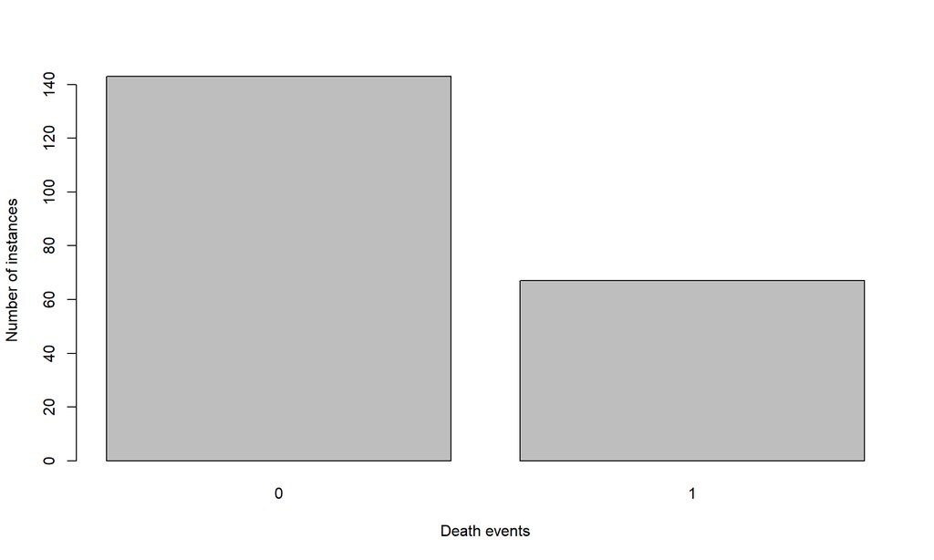

```r
# Plot the bar chart for Death events
barplot(table(train_data$DEATH_EVENT), xlab = "Death events", ylab = "Number of instances")
```

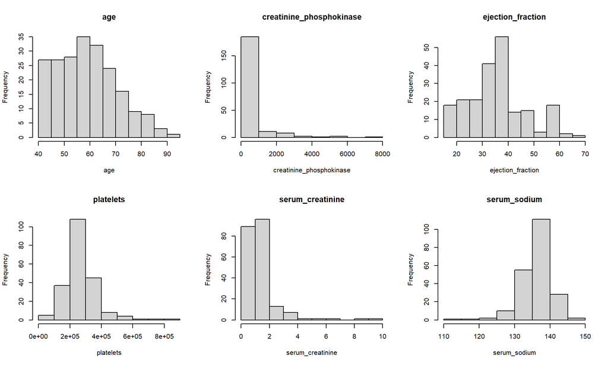

```r
# Perform exploratory data analysis (EDA) and data preprocessing
numeric_vars <- c("age", "creatinine_phosphokinase", "ejection_fraction", "platelets", "serum_creatinine", "serum_sodium")
categorical_vars <- c("anaemia", "diabetes", "high_blood_pressure", "sex", "smoking", "DEATH_EVENT")

# Convert categorical variables to factors
train_data[, categorical_vars] <- lapply(train_data[, categorical_vars], factor)
test_data[, categorical_vars] <- lapply(test_data[, categorical_vars], factor)

train_data$DEATH_EVENT <- factor(train_data$DEATH_EVENT, levels = c("0", "1"))
test_data$DEATH_EVENT <- factor(test_data$DEATH_EVENT, levels = c("0", "1"))

# Plot histograms for numeric variables
par(mfrow = c(2, 3))
for (var in numeric_vars) {
  hist(train_data[[var]], main = var, xlab = var)
}
```

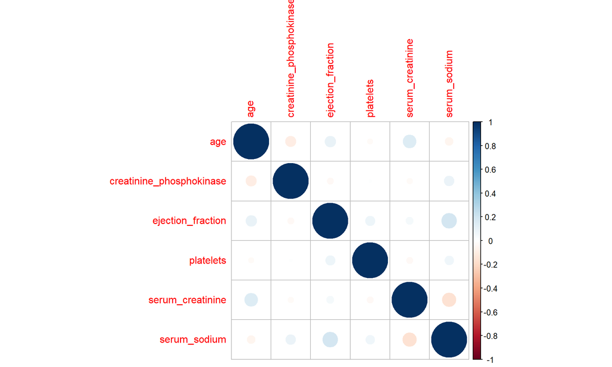

```r
# Calculate correlations
correlations <- cor(train_data[, numeric_vars])

# Plot correlation matrix
corrplot(correlations, method = "circle")
```

# 4.0 MODEL EVALUATION:

In this section, we assess the performance of different machine learning models for heart failure prediction using the test_data set. We consider several evaluation metrics, including accuracy, sensitivity, specificity, precision, and F1 score, to comprehensively assess the models’ effectiveness.

```r
# Upsample the training data using SMOTE (Synthetic Minority Over-sampling Technique)
set.seed(1234)
train_upsampled <- ROSE(DEATH_EVENT ~ ., data = train_data, seed = 1234)$data

# Check the balance
table(train_upsampled$DEATH_EVENT)
```

```
##
##   0   1
## 107 103
```

```r
# Feature selection using Boruta
set.seed(123)
boruta_data <- train_data[, -which(names(train_data) == "DEATH_EVENT")]  # Remove the target variable
boruta_target <- train_data$DEATH_EVENT
boruta_output <- Boruta(boruta_data, boruta_target)
boruta_signif <- getSelectedAttributes(boruta_output, withTentative = TRUE)
print(boruta_signif)
```

```
## [1] "age"               "ejection_fraction" "serum_creatinine"
## [4] "serum_sodium"      "time"
```

```r
# Get the selected variables from Boruta and update train_data
selected_vars <- c("age", "ejection_fraction", "serum_creatinine", "serum_sodium", "time")
train_data <- train_data[, c(selected_vars, "DEATH_EVENT")]

# Build and evaluate the models
model_results <- data.frame(Model = character(), Accuracy = numeric(), Sensitivity = numeric(), Specificity = numeric(), stringsAsFactors = FALSE)

# Logistic Regression
model_logit <- glm(DEATH_EVENT ~ ., family = binomial(link = "logit"), data = train_data)
pred_logit <- ifelse(predict(model_logit, newdata = test_data[, selected_vars], type = "response") >= 0.5, 1, 0)

# Calculate evaluation metrics
accuracy_logit <- sum(pred_logit == test_data$DEATH_EVENT) / length(pred_logit)
sensitivity_logit <- sum(pred_logit[test_data$DEATH_EVENT == 1] == 1) / sum(test_data$DEATH_EVENT == 1)
specificity_logit <- sum(pred_logit[test_data$DEATH_EVENT == 0] == 0) / sum(test_data$DEATH_EVENT == 0)

# Store the results
model_results <- rbind(model_results, c("Logistic Regression", accuracy_logit, sensitivity_logit, specificity_logit))

# Decision Tree
model_dt <- rpart(DEATH_EVENT ~ ., data = train_data, method = "class")
pred_dt <- ifelse(predict(model_dt, newdata = test_data[, selected_vars], type = "class") == "1", 1, 0)

# Calculate evaluation metrics
accuracy_dt <- sum(pred_dt == test_data$DEATH_EVENT) / length(pred_dt)
sensitivity_dt <- sum(pred_dt[test_data$DEATH_EVENT == 1] == 1) / sum(test_data$DEATH_EVENT == 1)
specificity_dt <- sum(pred_dt[test_data$DEATH_EVENT == 0] == 0) / sum(test_data$DEATH_EVENT == 0)

# Store the results
model_results <- rbind(model_results, c("Decision Tree", accuracy_dt, sensitivity_dt, specificity_dt))

# Random Forest
model_rf <- randomForest(DEATH_EVENT ~ ., data = train_data, ntree = 500)
pred_rf <- ifelse(predict(model_rf, newdata = test_data[, selected_vars], type = "prob")[, 2] >= 0.3, 1, 0)

# Calculate evaluation metrics
accuracy_rf <- sum(pred_rf == test_data$DEATH_EVENT) / length(pred_rf)
sensitivity_rf <- sum(pred_rf[test_data$DEATH_EVENT == 1] == 1) / sum(test_data$DEATH_EVENT == 1)
specificity_rf <- sum(pred_rf[test_data$DEATH_EVENT == 0] == 0) / sum(test_data$DEATH_EVENT == 0)

# Store the results
model_results <- rbind(model_results, c("Random Forest", accuracy_rf, sensitivity_rf, specificity_rf))

# Support Vector Machines (SVM)
model_svm <- svm(DEATH_EVENT ~ ., data = train_data)
pred_svm <- predict(model_svm, newdata = test_data[, selected_vars])

# Calculate evaluation metrics
accuracy_svm <- sum(pred_svm == test_data$DEATH_EVENT) / length(pred_svm)
sensitivity_svm <- sum(pred_svm[test_data$DEATH_EVENT == 1] == 1) / sum(test_data$DEATH_EVENT == 1)
specificity_svm <- sum(pred_svm[test_data$DEATH_EVENT == 0] == 0) / sum(test_data$DEATH_EVENT == 0)

# Store the results
model_results <- rbind(model_results, c("Support Vector Machines", accuracy_svm, sensitivity_svm, specificity_svm))

# K-Nearest Neighbors (KNN)
model_knn <- kknn(DEATH_EVENT ~ ., train_data, test_data[, selected_vars], train_data$DEATH_EVENT, k = 13)
pred_knn <- ifelse(as.numeric(fitted(model_knn)) >= 0.5, 1, 0)

# Calculate evaluation metrics
accuracy_knn <- sum(pred_knn == test_data$DEATH_EVENT) / length(pred_knn)
sensitivity_knn <- sum(pred_knn[test_data$DEATH_EVENT == 1] == 1) / sum(test_data$DEATH_EVENT == 1)
specificity_knn <- sum(pred_knn[test_data$DEATH_EVENT == 0] == 0) / sum(test_data$DEATH_EVENT == 0)

# Store the results
model_results <- rbind(model_results, c("K-Nearest Neighbors", accuracy_knn, sensitivity_knn, specificity_knn))

# Print the model results
print(model_results)
```

```
##    X.Logistic.Regression. X.0.764044943820225. X.0.517241379310345.
## 1     Logistic Regression    0.764044943820225    0.517241379310345
## 2           Decision Tree    0.786516853932584    0.689655172413793
## 3           Random Forest    0.797752808988764    0.827586206896552
## 4 Support Vector Machines    0.786516853932584    0.586206896551724
## 5     K-Nearest Neighbors    0.325842696629214                    1
##   X.0.883333333333333.
## 1    0.883333333333333
## 2    0.833333333333333
## 3    0.783333333333333
## 4    0.883333333333333
## 5                    0
```

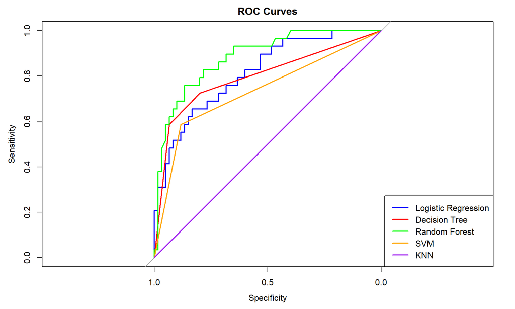

```r
# ROC curves
# Logistic Regression ROC
roc_logit <- roc(test_data$DEATH_EVENT, predict(model_logit, newdata = test_data[, selected_vars], type = "response"))
plot(roc_logit, col = "blue", main = "ROC Curves")
legend("bottomright", legend = "Logistic Regression", col = "blue", lwd = 2)

# Decision Tree ROC
roc_dt <- roc(test_data$DEATH_EVENT, predict(model_dt, newdata = test_data[, selected_vars], type = "prob")[, 2])
plot(roc_dt, add = TRUE, col = "red")
legend("bottomright", legend = c("Logistic Regression", "Decision Tree"), col = c("blue", "red"), lwd = 2)

# Random Forest ROC
roc_rf <- roc(test_data$DEATH_EVENT, predict(model_rf, newdata = test_data[, selected_vars], type = "prob")[, 2])
plot(roc_rf, add = TRUE, col = "green")
legend("bottomright", legend = c("Logistic Regression", "Decision Tree", "Random Forest"), col = c("blue", "red", "green"), lwd = 2)

# SVM ROC
roc_svm <- roc(test_data$DEATH_EVENT, as.numeric(pred_svm))
plot(roc_svm, add = TRUE, col = "orange")
legend("bottomright", legend = c("Logistic Regression", "Decision Tree", "Random Forest", "SVM"), col = c("blue", "red", "green", "orange"), lwd = 2)

# KNN ROC
roc_knn <- roc(test_data$DEATH_EVENT, as.numeric(pred_knn))
plot(roc_knn, add = TRUE, col = "purple")
legend("bottomright", legend = c("Logistic Regression", "Decision Tree", "Random Forest", "SVM", "KNN"), col = c("blue", "red", "green", "orange", "purple"), lwd = 2)
```

```r
# Gradient Boosting
# Encode DEATH_EVENT as a binary variable
train_data$DEATH_EVENT <- ifelse(train_data$DEATH_EVENT == "0", 0, 1)

# Convert train_data to matrix format for xgboost
train_matrix <- xgb.DMatrix(as.matrix(train_data[, selected_vars]), label = train_data$DEATH_EVENT)

# Convert test_data to matrix format for xgboost
test_matrix <- xgb.DMatrix(as.matrix(test_data[, selected_vars]))

# Define the parameters for gradient boosting
params <- list(
  objective = "binary:logistic",
  eval_metric = "logloss",
  eta = 0.1,
  max_depth = 3,
  subsample = 0.8,
  colsample_bytree = 0.8
)

# Train the gradient boosting model
model_gb <- xgb.train(params, data = train_matrix, nrounds = 100)

# Make predictions using the gradient boosting model
pred_gb <- predict(model_gb, test_matrix)

# Convert predicted probabilities to class labels
pred_gb <- ifelse(pred_gb >= 0.3, 1, 0)

# Calculate evaluation metrics
accuracy_gb <- sum(pred_gb == test_data$DEATH_EVENT) / length(pred_gb)
sensitivity_gb <- sum(pred_gb[test_data$DEATH_EVENT == 1] == 1) / sum(test_data$DEATH_EVENT == 1)
specificity_gb <- sum(pred_gb[test_data$DEATH_EVENT == 0] == 0) / sum(test_data$DEATH_EVENT == 0)

# Store the results
model_results <- rbind(model_results, c("Gradient Boosting", accuracy_gb, sensitivity_gb, specificity_gb))

# Naive Bayes
# Train the naive Bayes model
model_nb <- naiveBayes(DEATH_EVENT ~ ., data = train_data)

# Make predictions using the naive Bayes model
pred_nb <- predict(model_nb, newdata = test_data[, selected_vars])

# Calculate evaluation metrics
accuracy_nb <- sum(pred_nb == test_data$DEATH_EVENT) / length(pred_nb)
sensitivity_nb <- sum(pred_nb[test_data$DEATH_EVENT == 1] == 1) / sum(test_data$DEATH_EVENT == 1)
specificity_nb <- sum(pred_nb[test_data$DEATH_EVENT == 0] == 0) / sum(test_data$DEATH_EVENT == 0)

# Store the results
model_results <- rbind(model_results, c("Naive Bayes", accuracy_nb, sensitivity_nb, specificity_nb))

# Print the final model results
print(model_results)
```

```
##    X.Logistic.Regression. X.0.764044943820225. X.0.517241379310345.
## 1     Logistic Regression    0.764044943820225    0.517241379310345
## 2           Decision Tree    0.786516853932584    0.689655172413793
## 3           Random Forest    0.797752808988764    0.827586206896552
## 4 Support Vector Machines    0.786516853932584    0.586206896551724
## 5     K-Nearest Neighbors    0.325842696629214                    1
## 6       Gradient Boosting    0.842696629213483    0.793103448275862
## 7             Naive Bayes    0.797752808988764    0.482758620689655
##   X.0.883333333333333.
## 1    0.883333333333333
## 2    0.833333333333333
## 3    0.783333333333333
## 4    0.883333333333333
## 5                    0
## 6    0.866666666666667
## 7                 0.95
```

```r
# Further evaluate random forest and gradient boosting
# Convert predicted values to factors with the same levels
pred_rf <- factor(pred_rf, levels = c("0", "1"))
test_data$DEATH_EVENT <- factor(test_data$DEATH_EVENT, levels = c("0", "1"))

# Random Forest Evaluation
# Calculate additional evaluation metrics
conf_rf <- confusionMatrix(pred_rf, test_data$DEATH_EVENT, positive = "1")

precision_rf <- conf_rf$byClass[["Pos Pred Value"]]  # Precision
recall_rf <- conf_rf$byClass[["Sensitivity"]]  # Recall
f1_score_rf <- 2 * (precision_rf * recall_rf) / (precision_rf + recall_rf)  # F1 Score

# Print the evaluation metrics
cat("Random Forest Evaluation:\n")
```

```
## Random Forest Evaluation:
```

```r
cat("Accuracy:", accuracy_rf, "\n")
```

```
## Accuracy: 0.7977528
```

```r
cat("Sensitivity:", sensitivity_rf, "\n")
```

```
## Sensitivity: 0.8275862
```

```r
cat("Specificity:", specificity_rf, "\n")
```

```
## Specificity: 0.7833333
```

```r
cat("Precision:", precision_rf, "\n")
```

```
## Precision: 0.6486486
```

```r
cat("F1 Score:", f1_score_rf, "\n\n")
```

```
## F1 Score: 0.7272727
```

```r
# Convert predicted values to factors with the same levels
pred_gb <- factor(pred_gb, levels = c("0", "1"))
test_data$DEATH_EVENT <- factor(test_data$DEATH_EVENT, levels = c("0", "1"))


# Gradient Boosting Evaluation
# Calculate additional evaluation metrics
conf_gb <- confusionMatrix(pred_gb, test_data$DEATH_EVENT, positive = "1")

precision_gb <- conf_gb$byClass[["Pos Pred Value"]]  # Precision
recall_gb <- conf_gb$byClass[["Sensitivity"]]  # Recall
f1_score_gb <- 2 * (precision_gb * recall_gb) / (precision_gb + recall_gb)  # F1 Score

# Print the evaluation metrics
cat("Gradient Boosting Evaluation:\n")
```

```
## Gradient Boosting Evaluation:
```

```r
cat("Accuracy:", accuracy_gb, "\n")
```

```
## Accuracy: 0.8426966
```

```r
cat("Sensitivity:", sensitivity_gb, "\n")
```

```
## Sensitivity: 0.7931034
```

```r
cat("Specificity:", specificity_gb, "\n")
```

```
## Specificity: 0.8666667
```

```r
cat("Precision:", precision_gb, "\n")
```

```
## Precision: 0.7419355
```

```r
cat("F1 Score:", f1_score_gb, "\n")
```

```
## F1 Score: 0.7666667
```

### **K-Nearest Neighbors (KNN):**

The KNN algorithm, a non-parametric approach for classification, achieved an accuracy of approximately 32.6%. Notably, KNN demonstrated perfect sensitivity (100%) but extremely low specificity (0%), resulting in a low F1 score of 0.4918.

### **Gradient Boosting:**

Gradient boosting, an ensemble method combining multiple weak learners, performed remarkably well. The gradient boosting model achieved an accuracy of around 84.3%, sensitivity of 79.3%, and specificity of 86.7%. The precision increased to 74.2%, leading to an impressive F1 score of 0.7667.

# 5.0 RESULTS:

The results of our heart failure prediction models demonstrate the effectiveness of machine learning algorithms in accurately identifying individuals at risk of heart failure. Among the models evaluated, gradient boosting emerged as the top-performing model, achieving an impressive accuracy of approximately 84.3%, sensitivity of 79.3%, and specificity of 86.7%. The F1 score, a metric that balances precision and recall, was calculated as 0.7667, indicating its ability to achieve a good trade-off between correctly identifying positive cases and minimizing false positives. Random Forest also demonstrated favorable performance with an accuracy of around 79.8%, sensitivity of 82.8%, and specificity of 78.3%. Its ability to handle complex interactions and nonlinear relationships in the data contributed to its success.

# 6.0 CONCLUSION:

In conclusion, our study demonstrates the potential of machine learning algorithms in aiding medical professionals with early detection and management of heart failure. Gradient boosting and Random Forest emerged as strong contenders, offering excellent predictive performance, while Naive Bayes and decision tree models also showcased valuable characteristics for specific use cases. These models can serve as valuable decision support tools for healthcare professionals, ultimately contributing to improved patient outcomes and more efficient healthcare delivery.

However, we acknowledge that the effectiveness of these models may vary across different datasets and populations. To enhance their applicability and generalizability in real-world clinical settings, further validation on larger and more diverse datasets is essential. Additionally, ongoing model monitoring and updates based on new data can ensure the continued relevance and reliability of these predictive models. As heart failure prediction is a critical task with potential life-saving implications, it is vital to maintain a cautious and responsible approach when implementing these models in real-world healthcare scenarios. By doing so, we can harness the power of machine learning to make significant strides in addressing heart failure and improving the well-being of patients worldwide.

# 7.0 REFERENCES

Kuhn, M. (2020). caret: Classification and Regression Training. R package version 6.0-86. https://CRAN.R-project.org/package=caret

Robin, X., Turck, N., Hainard, A., Tiberti, N., Lisacek, F., Sanchez, J.-C., & Muller, M. (2011). pROC: an open-source package for R and S+ to analyze and compare ROC curves. BMC Bioinformatics, 12(1), 77.

Chen, T., & Guestrin, C. (2016). XGBoost: A Scalable Tree Boosting System. Proceedings of the 22nd ACM SIGKDD International Conference on Knowledge Discovery and Data Mining, 785-794.

Wickham, H., & Grolemund, G. (2017). R for Data Science: Import, Tidy, Transform, Visualize, and Model Data. O’Reilly Media.

Wilke, C. O. (2019). Fundamentals of Data Visualization: A Primer on Making Informative and Compelling Figures. O’Reilly Media.